# Exercise 5

Tiina Siponen

22.11.2019

# Exercise 5

*Work summary* Codes are available at

- https://github.com/tiinasip/IODS-project/blob/master/human.R
- https://github.com/tiinasip/IODS-project/blob/master/human2.R

## Data wrangling

Data set is about human development indeces (HDI). United Nations Development Programme has collected it and it contains many indeces that can be used for evaluating nation’s development in human outcomes. Traditional economic GNI values alone do not describe the humanity of the state and therefore complementary measures are needed. Such measures are for instance life expectancy, population with secondary education (female/male) etc. More information about the HDI is found [here](http://hdr.undp.org/en/content/human-development-index-hdi)

Data is loaded from the given address

```r
human <- read.table("http://s3.amazonaws.com/assets.datacamp.com/production/course_2218/datasets/human1.txt", sep  =",", header = T)
```

Next I check the data structure and check that the variables are the same I expected.

```r
str(human)
```

```
## 'data.frame':    195 obs. of  19 variables:
##  $ HDI.Rank      : int  1 2 3 4 5 6 6 8 9 9 ...
##  $ Country       : Factor w/ 195 levels "Afghanistan",..: 129 10 169 48 124 67 84 186 34 125 ...
##  $ HDI           : num  0.944 0.935 0.93 0.923 0.922 0.916 0.916 0.915 0.913 0.913 ...
##  $ Life.Exp      : num  81.6 82.4 83 80.2 81.6 80.9 80.9 79.1 82 81.8 ...
##  $ Edu.Exp       : num  17.5 20.2 15.8 18.7 17.9 16.5 18.6 16.5 15.9 19.2 ...
##  $ Edu.Mean      : num  12.6 13 12.8 12.7 11.9 13.1 12.2 12.9 13 12.5 ...
##  $ GNI           : Factor w/ 194 levels "1,096","1,123",..: 166 135 156 139 140 137 127 154 134 117 ...
##  $ GNI.Minus.Rank: int  5 17 6 11 9 11 16 3 11 23 ...
##  $ GII.Rank      : int  1 2 3 4 5 6 6 8 9 9 ...
##  $ GII           : num  0.067 0.11 0.028 0.048 0.062 0.041 0.113 0.28 0.129 0.157 ...
##  $ Mat.Mor       : int  4 6 6 5 6 7 9 28 11 8 ...
##  $ Ado.Birth     : num  7.8 12.1 1.9 5.1 6.2 3.8 8.2 31 14.5 25.3 ...
##  $ Parli.F       : num  39.6 30.5 28.5 38 36.9 36.9 19.9 19.4 28.2 31.4 ...
##  $ Edu2.F        : num  97.4 94.3 95 95.5 87.7 96.3 80.5 95.1 100 95 ...
##  $ Edu2.M        : num  96.7 94.6 96.6 96.6 90.5 97 78.6 94.8 100 95.3 ...
##  $ Labo.F        : num  61.2 58.8 61.8 58.7 58.5 53.6 53.1 56.3 61.6 62 ...
##  $ Labo.M        : num  68.7 71.8 74.9 66.4 70.6 66.4 68.1 68.9 71 73.8 ...
##  $ Edu2.FM       : num  1.007 0.997 0.983 0.989 0.969 ...
##  $ Labo.FM       : num  0.891 0.819 0.825 0.884 0.829 ...
```

```r
names(human)
```

```
##  [1] "HDI.Rank"       "Country"        "HDI"            "Life.Exp"
##  [5] "Edu.Exp"        "Edu.Mean"       "GNI"            "GNI.Minus.Rank"
##  [9] "GII.Rank"       "GII"            "Mat.Mor"        "Ado.Birth"
## [13] "Parli.F"        "Edu2.F"         "Edu2.M"         "Labo.F"
## [17] "Labo.M"         "Edu2.FM"        "Labo.FM"
```

```r
human$GNI <- as.numeric(human$GNI)
str(human$GNI)
```

```
##  num [1:195] 166 135 156 139 140 137 127 154 134 117 ...
```

```r
library(dplyr)
human <- read.table("http://s3.amazonaws.com/assets.datacamp.com/production/course_2218/datasets/human1.txt", sep  =",", header = T)
human$GNI <- as.numeric(human$GNI)
keep <- c("Country", "Edu2.FM", "Labo.FM", "Life.Exp", "Edu.Exp", "GNI", "Mat.Mor", "Ado.Birth", "Parli.F")
human <- select(human, one_of(keep))
data.frame(human[-1], comp = complete.cases(human))
```

```
##       Edu2.FM   Labo.FM Life.Exp Edu.Exp GNI Mat.Mor Ado.Birth Parli.F
## 1   1.0072389 0.8908297     81.6    17.5 166       4       7.8    39.6
## 2   0.9968288 0.8189415     82.4    20.2 135       6      12.1    30.5
## 3   0.9834369 0.8251001     83.0    15.8 156       6       1.9    28.5
## 4   0.9886128 0.8840361     80.2    18.7 139       5       5.1    38.0
## 5   0.9690608 0.8286119     81.6    17.9 140       6       6.2    36.9
## 6   0.9927835 0.8072289     80.9    16.5 137       7       3.8    36.9
## 7   1.0241730 0.7797357     80.9    18.6 127       9       8.2    19.9
## 8   1.0031646 0.8171263     79.1    16.5 154      28      31.0    19.4
## 9   1.0000000 0.8676056     82.0    15.9 134      11      14.5    28.2
## 10  0.9968520 0.8401084     81.8    19.2 117       8      25.3    31.4
## 11  0.9148148 0.7616580     83.0    15.4 180       6       6.0    25.3
## 12  0.9116162 0.7566372     84.0    15.6 155      NA       3.3      NA
## 13         NA        NA     80.0    15.0 181      NA        NA    20.0
## 14  0.9908362 0.8880707     82.2    15.8 141       4       6.5    43.6
```

[output cut: 377 more lines]

```r
# filter out all rows with NA values
human_ <- filter(human, complete.cases(human))
tail(human_,10)
```

```
##                             Country   Edu2.FM   Labo.FM Life.Exp Edu.Exp
## 153                            Chad 0.1717172 0.8080808     51.6     7.4
## 154        Central African Republic 0.3782772 0.8531140     50.7     7.2
## 155                           Niger 0.3076923 0.4459309     61.4     5.4
## 156                     Arab States 0.7289916 0.3081009     70.6    12.0
## 157       East Asia and the Pacific 0.8250377 0.7884131     74.0    12.7
## 158         Europe and Central Asia 0.8784119 0.6514286     72.3    13.6
## 159 Latin America and the Caribbean 0.9836957 0.6729323     75.0    14.0
## 160                      South Asia 0.5329670 0.3711083     68.4    11.2
## 161              Sub-Saharan Africa 0.7015873 0.8537859     58.5     9.6
## 162                           World 0.8333333 0.6558018     71.5    12.2
##     GNI Mat.Mor Ado.Birth Parli.F
## 153  66     980     152.0    14.9
## 154 158     880      98.3    12.5
## 155 194     630     204.8    13.3
## 156  52     155      45.4    14.0
## 157  27      72      21.2    18.7
## 158  36      28      30.8    19.0
## 159  44      85      68.3    27.0
## 160 151     183      38.7    17.5
## 161 107     506     109.7    22.5
## 162  45     210      47.4    21.8
```

```r
last <- nrow(human_) - 7
human_ <- human[1:last, ]
rownames(human_) <- human_$Country
#country names column removal
human_ <- select(human_, -Country)
dim(human_)
```

```
## [1] 155   8
```

```r
human <-human_
str(human)
```

```
## 'data.frame':    155 obs. of  8 variables:
##  $ Edu2.FM  : num  1.007 0.997 0.983 0.989 0.969 ...
##  $ Labo.FM  : num  0.891 0.819 0.825 0.884 0.829 ...
##  $ Life.Exp : num  81.6 82.4 83 80.2 81.6 80.9 80.9 79.1 82 81.8 ...
##  $ Edu.Exp  : num  17.5 20.2 15.8 18.7 17.9 16.5 18.6 16.5 15.9 19.2 ...
##  $ GNI      : num  166 135 156 139 140 137 127 154 134 117 ...
##  $ Mat.Mor  : int  4 6 6 5 6 7 9 28 11 8 ...
##  $ Ado.Birth: num  7.8 12.1 1.9 5.1 6.2 3.8 8.2 31 14.5 25.3 ...
##  $ Parli.F  : num  39.6 30.5 28.5 38 36.9 36.9 19.9 19.4 28.2 31.4 ...
```

Not all the rows are countries and therefore regions are taken out. The number of rows decreases to 155 and there are 8 variables as it should be.

## Data analysis

Although my data wrangling part seemed to be successfull, I read the wrangled data set and name it to human2.

```r
human2 <- read.table("http://s3.amazonaws.com/assets.datacamp.com/production/course_2218/datasets/human2.txt", sep  =",", header = T)
str(human2)
```

```
## 'data.frame':    155 obs. of  8 variables:
##  $ Edu2.FM  : num  1.007 0.997 0.983 0.989 0.969 ...
##  $ Labo.FM  : num  0.891 0.819 0.825 0.884 0.829 ...
##  $ Edu.Exp  : num  17.5 20.2 15.8 18.7 17.9 16.5 18.6 16.5 15.9 19.2 ...
##  $ Life.Exp : num  81.6 82.4 83 80.2 81.6 80.9 80.9 79.1 82 81.8 ...
##  $ GNI      : int  64992 42261 56431 44025 45435 43919 39568 52947 42155 32689 ...
##  $ Mat.Mor  : int  4 6 6 5 6 7 9 28 11 8 ...
##  $ Ado.Birth: num  7.8 12.1 1.9 5.1 6.2 3.8 8.2 31 14.5 25.3 ...
##  $ Parli.F  : num  39.6 30.5 28.5 38 36.9 36.9 19.9 19.4 28.2 31.4 ...
```

### Dimensions analysis

As catter plot matrix shows, Edu.Exp, Parli.F and Edu2.FM seem to be quite normally distributed. Ado.Birth, Mat.Mor and GNI are skewed to the right. Labo.FM is skewed to the left.

```r
library(GGally)
```

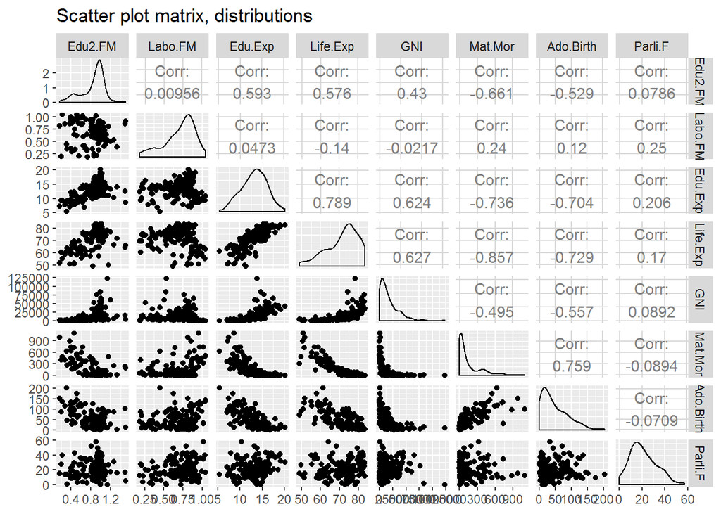

```r
library(ggplot2)
ggpairs(human2, mapping = aes(), title="Scatter plot matrix, distributions ",lower = list(combo = wrap("facethist", bins = 20)))
```

```r
summary(human2)
```

```
##     Edu2.FM          Labo.FM          Edu.Exp         Life.Exp
##  Min.   :0.1717   Min.   :0.1857   Min.   : 5.40   Min.   :49.00
##  1st Qu.:0.7264   1st Qu.:0.5984   1st Qu.:11.25   1st Qu.:66.30
##  Median :0.9375   Median :0.7535   Median :13.50   Median :74.20
##  Mean   :0.8529   Mean   :0.7074   Mean   :13.18   Mean   :71.65
##  3rd Qu.:0.9968   3rd Qu.:0.8535   3rd Qu.:15.20   3rd Qu.:77.25
##  Max.   :1.4967   Max.   :1.0380   Max.   :20.20   Max.   :83.50
##       GNI            Mat.Mor         Ado.Birth         Parli.F
##  Min.   :   581   Min.   :   1.0   Min.   :  0.60   Min.   : 0.00
##  1st Qu.:  4198   1st Qu.:  11.5   1st Qu.: 12.65   1st Qu.:12.40
##  Median : 12040   Median :  49.0   Median : 33.60   Median :19.30
##  Mean   : 17628   Mean   : 149.1   Mean   : 47.16   Mean   :20.91
##  3rd Qu.: 24512   3rd Qu.: 190.0   3rd Qu.: 71.95   3rd Qu.:27.95
##  Max.   :123124   Max.   :1100.0   Max.   :204.80   Max.   :57.50
```

Expected years of education and life expectancy are most strongly positively correlated.The strongest negative correlation is between maternal mortality ratio and life expectancy. On the other hand, gross national income & Labour Force Participation Rate (Female) and Population with Secondary Education (Female) & Labour Force Participation Rate (Female) seem not to correlate at all. This is clearly visible also in correlation matrix visualization

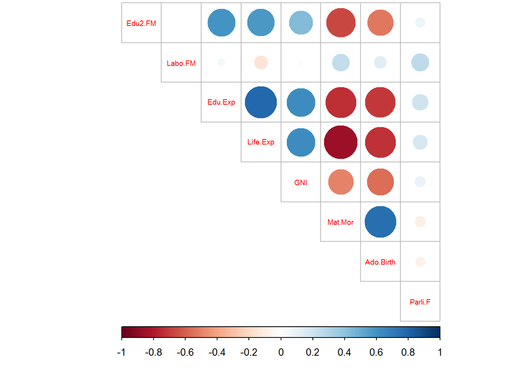

```r
library(corrplot)
cor_matrix<-cor(human2)
corrplot(cor_matrix, method="circle", type="upper",cl.pos="b", tl.pos="d", tl.cex=0.6)
```

### PCA analysis

The first PCA is created with non-standardised data.

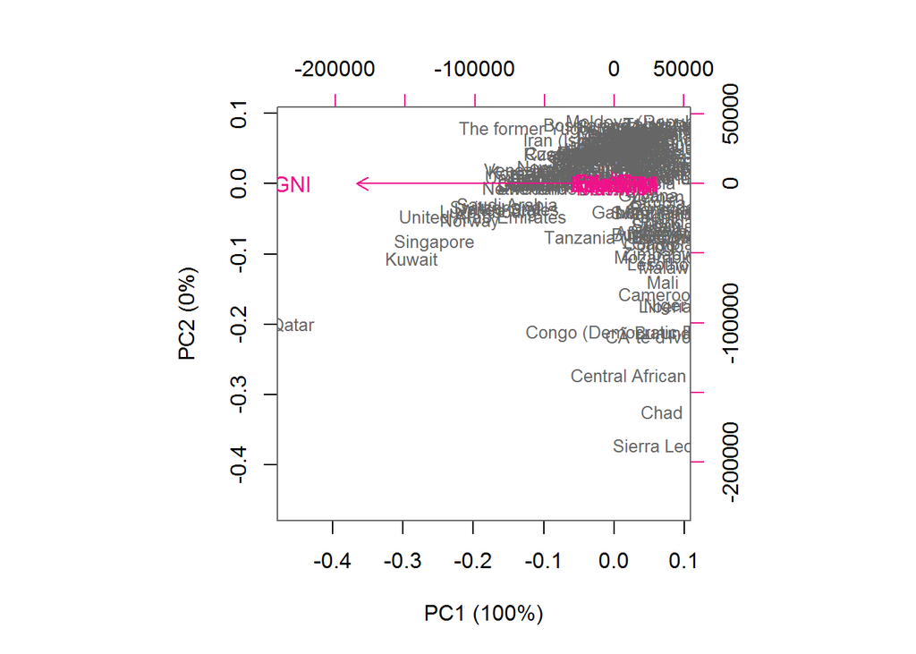

```r
pca_human <- prcomp(human2)
s<-summary(pca_human)
pca_pr_nonst <- round(100*s$importance[2,], digits = 1)
pc_lab_nonst <- paste0(names(pca_pr_nonst), " (", pca_pr_nonst, "%)")
biplot(pca_human, cex = c(0.8, 1), col = c("grey40", "deeppink2"), xlab = pc_lab_nonst[1], ylab = pc_lab_nonst[2])
```

```r
pca_pr_nonst
```

```
## PC1 PC2 PC3 PC4 PC5 PC6 PC7 PC8
## 100   0   0   0   0   0   0   0
```

The picture difficult to interpret. GNI has the biggest variance here and it stands out. Printing out the variance percentages shows clearly how the PC1 seems to capture all the variance. Also the loading values are very large. However, next then the same is done with standardized data

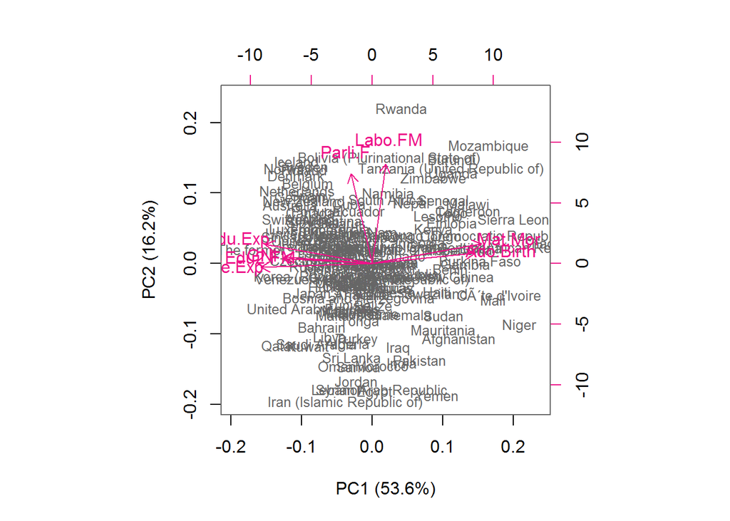

```r
human_std <- scale(human2)
pca_human2 <- prcomp(human_std)
s<-summary(pca_human2)
pca_pr <- round(100*s$importance[2,], digits = 1)
pc_lab <- paste0(names(pca_pr), " (", pca_pr, "%)")
biplot(pca_human2, cex = c(0.8, 1), col = c("grey40", "deeppink2"), xlab = pc_lab[1], ylab = pc_lab[2])
```

```r
pca_pr
```

```
##  PC1  PC2  PC3  PC4  PC5  PC6  PC7  PC8
## 53.6 16.2  9.6  7.6  5.5  3.6  2.6  1.3
```

It is obvious that standardisation is required before PCA in this case. In fact, it is usually recommended, because PCA is sensitive to the relative scaling of the original features and assumes features with larger variance to be more important to those with smaller variance.

With standardization, GNI is no longer as strongly standing out but it is possible to see other variables as well. Gross National Income naturally creates very large numbers in comparison e.g. life-expectansy that is not usually over 80 years. Without standardisation GNI is overemphasized.

When standardized biplot is analysed, Labour Force Participation Rate (Female) and Percent Female Representation in Parliament have small angle and they are positively correlated meaning that the countries where females are active in labour force have them in the parliament as well. They also strongly contribute to PC2.

Maternal mortality ratio and Adolescent Birth Rate point to the same direction with small angle with each other. They are strongly positively correlated with each other. These components are also contributing to PC1. From the content perspective this is very logical. When girls are not educated - meaning families and the society are not investing in them - they are in higher risk to be married as children, and when they don’t have education, own income and status, their healthy needs are not seen important in the society.

The remaining variables show to the opposite direction. Those variables are Population with Secondary Education (Female), Expected Years of Education, Gross National Income (GNI) per Capita and Life Expectancy at Birth. They are positively correlated with each other and negatively correlated with maternal mortality ratio and adolescent birth rate. These components are also contributing negatively to PC1.

The correlation matrix confirms correlations.

```r
cor_matrix<-round(cor(human2), digits=2)
cor_matrix
```

```
##           Edu2.FM Labo.FM Edu.Exp Life.Exp   GNI Mat.Mor Ado.Birth Parli.F
## Edu2.FM      1.00    0.01    0.59     0.58  0.43   -0.66     -0.53    0.08
## Labo.FM      0.01    1.00    0.05    -0.14 -0.02    0.24      0.12    0.25
## Edu.Exp      0.59    0.05    1.00     0.79  0.62   -0.74     -0.70    0.21
## Life.Exp     0.58   -0.14    0.79     1.00  0.63   -0.86     -0.73    0.17
## GNI          0.43   -0.02    0.62     0.63  1.00   -0.50     -0.56    0.09
## Mat.Mor     -0.66    0.24   -0.74    -0.86 -0.50    1.00      0.76   -0.09
## Ado.Birth   -0.53    0.12   -0.70    -0.73 -0.56    0.76      1.00   -0.07
## Parli.F      0.08    0.25    0.21     0.17  0.09   -0.09     -0.07    1.00
```

```r
pca_human2
```

```
## Standard deviations (1, .., p=8):
## [1] 2.0708380 1.1397204 0.8750485 0.7788630 0.6619563 0.5363061 0.4589994
## [8] 0.3222406
##
## Rotation (n x k) = (8 x 8):
##                   PC1         PC2         PC3         PC4        PC5
## Edu2.FM   -0.35664370  0.03796058 -0.24223089  0.62678110 -0.5983585
## Labo.FM    0.05457785  0.72432726 -0.58428770  0.06199424  0.2625067
## Edu.Exp   -0.42766720  0.13940571 -0.07340270 -0.07020294  0.1659678
## Life.Exp  -0.44372240 -0.02530473  0.10991305 -0.05834819  0.1628935
## GNI       -0.35048295  0.05060876 -0.20168779 -0.72727675 -0.4950306
## Mat.Mor    0.43697098  0.14508727 -0.12522539 -0.25170614 -0.1800657
## Ado.Birth  0.41126010  0.07708468  0.01968243  0.04986763 -0.4672068
## Parli.F   -0.08438558  0.65136866  0.72506309  0.01396293 -0.1523699
##                   PC6         PC7         PC8
## Edu2.FM    0.17713316  0.05773644  0.16459453
## Labo.FM   -0.03500707 -0.22729927 -0.07304568
## Edu.Exp   -0.38606919  0.77962966 -0.05415984
## Life.Exp  -0.42242796 -0.43406432  0.62737008
## GNI        0.11120305 -0.13711838 -0.16961173
## Mat.Mor    0.17370039  0.35380306  0.72193946
## Ado.Birth -0.76056557 -0.06897064 -0.14335186
## Parli.F    0.13749772  0.00568387 -0.02306476
```

In PC1 the most meaningful components are life expectancy to one direction and maternal mortality to the other direction. As a whole, the meaningful components in PC1 are referring life expectancy as a whole. When a woman’s life is valued, she is educated, given opportunites, taken caren of at labour and thus she lives longer.

In PC2 Labour Force Participation Rate (Female) and Percent Female Representation in Parliament are the most meaningful components.These metrics could be grouped as “Women attendance rate in society”. PC1 explains 53,6 % and PC2 16,2%. In other words, factors related to the life excpectancy explain the most and factors related to women attendance rate in the society covers about 16 %. Next groupings are under 10 %.

## Tea set

The data used here is based on a questionnaire on tea. 300 individuals were asked how they drink tea (18 questions), what are their product’s perception (12 questions) and some personal details (4 questions).

```r
#install.packages("FactoMineR")
library(FactoMineR)
library(dplyr)
library(MASS)
library(tidyr)
library(stringr)
tea_time <-tea
summary(tea_time)
str(tea_time)
dim(tea_time)
```

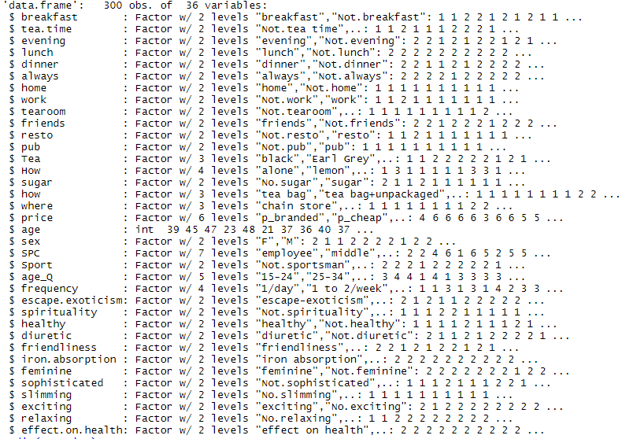

str

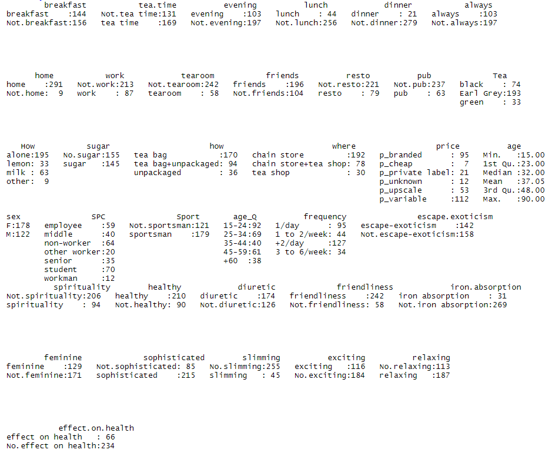

summary

```r
keep_columns <- c("Tea", "How", "how", "sugar", "where", "lunch","where","price","lunch","friends","friendliness")
tea_time2 <- select(tea, keep_columns)
mca_tea <- MCA(tea_time2, graph = FALSE)
summary(mca_tea)
print(mca_tea)
```

[output not shown]

MCA graphs and factor map are created

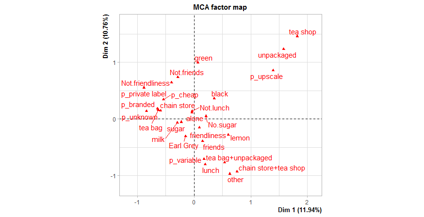

```r
mca_tea <- MCA(tea_time2, graph = TRUE)
plot(mca_tea, invisible=c("ind"))
```

Closer look to eigenvalues shows that the first MCA dimension covers almost 12% of variance and 6 dimensions reach over 50 %.

```r
library(factoextra)
eig.val <- get_eigenvalue(mca_tea)
head(eig.val)
```

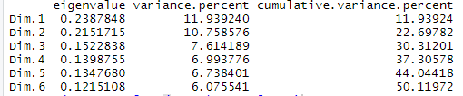

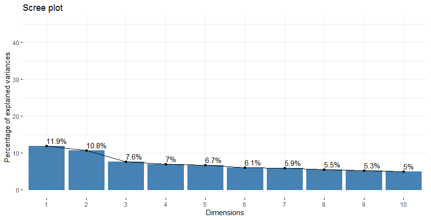

```r
fviz_screeplot(mca_tea, addlabels = TRUE, ylim = c(0, 45))
```

Next I tried biplot drawing, where individuals are in blue and variables in red. But this was too wild to make any real analysis. The distance between any row points or column points should give a measure of their similarity (or dissimilarity). Row points with similar profile are close on the factor map. The same holds true for column points. But anyway, one can see that for instance individuals 212 and 199 are very similar.

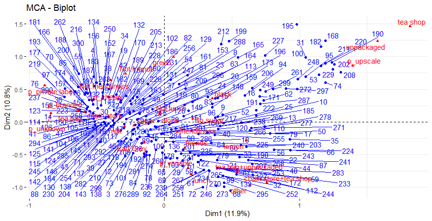

```r
fviz_mca_biplot(mca_tea,
                repel = TRUE, # Avoid text overlapping (slow if many point)
                ggtheme = theme_minimal())
```

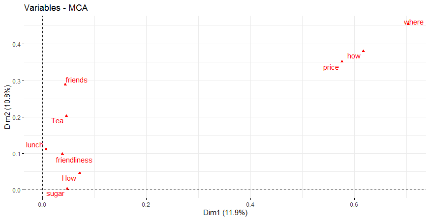

```r
fviz_mca_var(mca_tea, choice = "mca.cor",
             repel = TRUE, # Avoid text overlapping (slow)
             ggtheme = theme_minimal())
```

Here similar variable categories are grouped toghether. Negative correlation is in opposite directions; for instance, p_private label and chain stroe+tea shop are negatively correlated

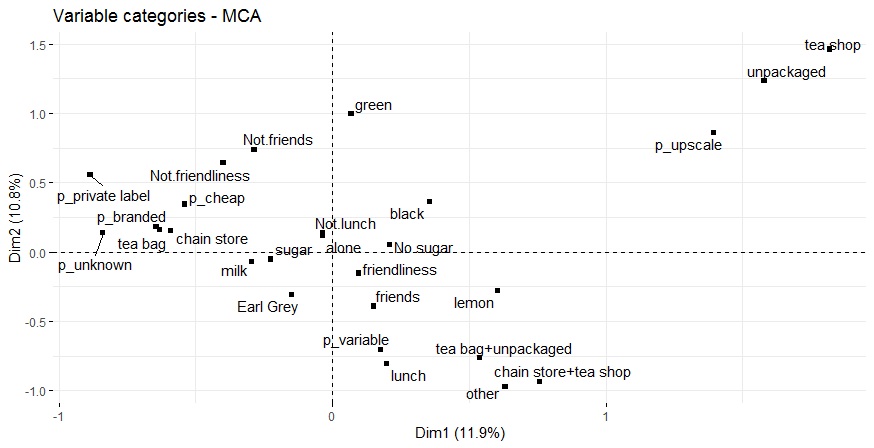

```r
fviz_mca_var(mca_tea, col.var="black", shape.var = 15,
             repel = TRUE)
```

In the end I analyse, which top 20 variable categories contributes most to dimensions 1 and 2. Tea shop is contributing the second most in both dimensions. P_upscale is contributing over 15 % in dimension 1 and chainstore+tea shop abou 11 % in dimension 2.

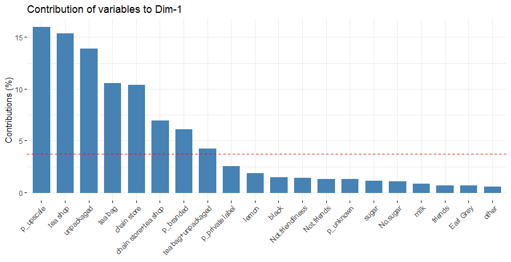

```r
fviz_contrib(mca_tea, choice = "var", axes = 1, top = 20)
```

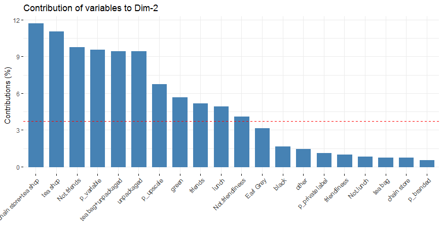

```r
fviz_contrib(mca_tea, choice = "var", axes = 2, top = 20)
```